# Unlocking Non-Traditional Data for Risk Analytics

By *Rendani Mbuvha, School of Statistics and Actuarial Science University of Witwatersrand*

# *Predictive Modeling With Text Features*

This notebook provides a short tutorial in building predictive models using text. The approach we take here is using the Bag of Words or the Document Term Matrix (DTM) technique. This is essentially representing documents by the relative occurrences of different words from set vocabulary. Counts can be of single words or of N-consecutive words (N-grams). This exercise will focus on single word counts (unigrams) and two consecutive word counts (bigrams).

## **Preliminaries - To be done before workshop**

First of all, we need to install R, R studio, and the required packages (where required).

- Download and install R according to the instructions [here] (https://cran.rstudio.com/)
- Download and install R studio according to instructions [here](https://www.rstudio.com/products/rstudio/download/#download) (*Optional*)

In R install libraries:

- text2vec
- ROCR
- ggplot2
- glmnet

> Use the command *install.packages(“package-name”)*

Set working directory to the folder where you would to save your work.

```r
setwd("~/Dropbox/Teaching/ASSA_Workshop/")
```

Load the required libraries

```r
# Main library for NLP
library(text2vec)
# For model evaluation calc
library(ROCR)
#Gives nice plots
library(ggplot2)
#glms..
library(glmnet)
```

### The Dataset

The dataset for this tutorial consists of 5000 IMDB movie reviews, specially selected for sentiment analysis. The sentiment of the reviews is binary, meaning an IMDB rating < 5 results in a sentiment score of 0, and a rating >=7 has a sentiment score of 1. No individual movie had more than 30 reviews.

The aim of this tutorial is to predict a movie’s sentiment based on a vectorized representation of the words contained in the movie’s review.

Possible areas in the financial services industry where such modeling techniques can be used include:

- Fraud Detection
- Media Monitoring
- Sales practice monitoring
- Investment market sentiment analysis
- Medical note analysis

Load the IMDb movie review dataset. And perform some preprocessing.

```r
data("movie_review")
#Clean up the review
movie_review$review = gsub('b"|b\'|\n|\\\\|\\"', "", movie_review$review)
movie_review$review = gsub("([<>])|[[:punct:]]", "\\1", movie_review$review)
#Randomly sample training records
training_ids = sample(1:5000,3500)
testing_ids = setdiff(1:5000,training_ids)
#Creating  subsets.
training = movie_review[training_ids,]
testing = movie_review[testing_ids,]
head(training)
```

|  | id | sentiment | review |
| --- | --- | --- | --- |
| 4500 | 11600_3 | 0 | After the success of Part 4 another sequel was a natural move However they should have stopped it before it began Alice having survived Part 4 finds herself pregnant and it seems Freddy is using her u… |
| 964 | 2827_10 | 1 | This is probably one of the worst movies ever made Itsterrible But its so good Its probably best if you dont watch it expecting a gripping plot and something fantastically clever and entertaining beca… |
| 4538 | 2061_1 | 0 | The only film Ive ever walked out on Amazing since I paid for myself and my date and Im really cheap But my brain couldnt stand any more of the dreck being piled on particularly since I could have wri… |
| 2890 | 6613_4 | 0 | Iam a Big fan of Mr Ram Gopal Varma but i could not believe that he made this movie i was really disappointedRam Gopal Varma Ki Aag doesnt come anywhere close to the real Sholay It does not leave a la… |
| 739 | 4209_7 | 1 | Pickup On South Street is a high speed drama about a small time criminal who suddenly finds himself embroiled in the activities of a group of communists The action is presented in a very direct and dy… |
| 3196 | 4418_10 | 1 | Saw this at the Hawaii Film Festival where the director and his wife who produced it took a QA afterwardsI found it hard to believe this is a first time director and all kudos to Harvey Keitel for onc… |

### Unigram Modeling

The next step will be to split documents (reviews) into separate words(Tokenize).

```r
#Words to skip - to avoid inflated counts
stop_words = c("the","to","of","for","br","this","for", "in","a","b","and","on","is","by","that","with","from","as","it","are","have","be","us","an","was","u","i")
#Tokenize the documents
train_tokens = itoken(training$review,
             preprocessor = tolower,
             tokenizer = word_tokenizer,
             ids = training$id,
             progressbar = TRUE)
```

Create universe of words from the entire training dataset. This is referred to as the vocabulary or dictionary of the problem.

```r
vocab = create_vocabulary(train_tokens,stopwords = stop_words)
#Trim the vocabulary a little bit
pruned_vocab = prune_vocabulary(vocab,term_count_min = 10, doc_proportion_max = 0.95, doc_proportion_min = 0.001, vocab_term_max = 1000)
```

Now we are able to create our text features/rating factors. This is done by simply vectorizing each review by the counts of each word (from the vocabulary) that is represented in the document. Simply this is effectively scoring through the vocabulary. This creates what is called a bag-of-words or a document term matrix (DTM).

```r
#Index each token
  vectorizer = vocab_vectorizer(pruned_vocab)
#bin counts falling into each token
  dtm_train = create_dtm(train_tokens, vectorizer)
```

Just a quick check on our DTM

```r
# Dimension check
dim(dtm_train)
```

```
[1] 3500 1000
```

```r
# check the first 6 rows
head(data.frame(as.matrix(dtm_train)))
```

|  | but | movie | film | not | you | his | he | its | one | at | all | they | who | like | so | her | or | about | just | if. | has | some | out | there | good | what | when | more | very | … |
| --- | --- | --- | --- | --- | --- | --- | --- | --- | --- | --- | --- | --- | --- | --- | --- | --- | --- | --- | --- | --- | --- | --- | --- | --- | --- | --- | --- | --- | --- | --- |
| 11600_3 | 1 | 2 | 0 | 1 | 0 | 1 | 0 | 0 | 0 | 1 | 0 | 1 | 0 | 0 | 0 | 1 | 0 | 0 | 0 | 0 | 0 | 0 | 0 | 0 | 1 | 0 | 0 | 0 | 1 | … |
| 2827_10 | 1 | 0 | 2 | 1 | 4 | 0 | 2 | 2 | 1 | 0 | 0 | 1 | 1 | 0 | 2 | 0 | 1 | 2 | 0 | 2 | 0 | 0 | 1 | 0 | 1 | 0 | 1 | 0 | 0 | … |
| 2061_1 | 2 | 0 | 4 | 0 | 0 | 0 | 0 | 1 | 0 | 0 | 0 | 0 | 0 | 0 | 0 | 0 | 0 | 0 | 0 | 0 | 0 | 0 | 1 | 0 | 0 | 1 | 0 | 1 | 0 | … |
| 6613_4 | 4 | 4 | 0 | 3 | 0 | 0 | 3 | 0 | 0 | 0 | 1 | 0 | 0 | 0 | 0 | 0 | 0 | 1 | 1 | 0 | 0 | 0 | 0 | 3 | 0 | 0 | 0 | 1 | 0 | … |
| 4209_7 | 3 | 0 | 0 | 0 | 0 | 5 | 6 | 2 | 4 | 1 | 1 | 3 | 3 | 1 | 1 | 13 | 1 | 3 | 0 | 2 | 3 | 2 | 1 | 2 | 0 | 1 | 5 | 2 | 1 | … |
| 4418_10 | 0 | 1 | 2 | 0 | 0 | 1 | 1 | 1 | 0 | 1 | 1 | 0 | 1 | 0 | 0 | 0 | 0 | 1 | 0 | 0 | 0 | 1 | 2 | 0 | 0 | 0 | 0 | 0 | 0 | … |

Train a simple GLM on the above created features to predict sentiment.

```r
set.seed(201L)
NFOLDS = 4
#row normalize the data
dtm_train_norm = normalize(dtm_train, "l1")
unigram_classifier = cv.glmnet(x = dtm_train_norm, y = training$sentiment,
                              family = 'binomial',
                              alpha = 1,
                              type.measure = "auc",
                              nfolds = NFOLDS,
                              thresh = 1e-3)
```

Prepare the testing set by tokenizing and vectorizing using the training scheme.

```r
testing_tokens = itoken(testing$review,
                        ids = testing$id,
                        prep_fun= tolower,
                        tokenizer =word_tokenizer,
                        progressbar = TRUE)
dtm_test = create_dtm(testing_tokens, vectorizer)
#row normalize the data
dtm_test_norm = normalize(dtm_test, "l1")
preds = predict(unigram_classifier , dtm_test_norm  , type = 'response',s = "lambda.min")
```

Evaluate model performance

```r
#Create a prediction object
prediction = prediction(preds, testing$sentiment)
#infer True postive and false positve rates
perf = performance(prediction, measure = "tpr", x.measure = "fpr")

#accuracy and area under the curve
acc = performance(prediction, measure = "acc")
max(acc@y.values[[1]])
```

```
[1] 0.8193333
```

```r
auc = performance(prediction, measure = "auc")
auc@y.values
```

```
[[1]]
[1] 0.9003882
```

Plot accuracy at different cutoffs

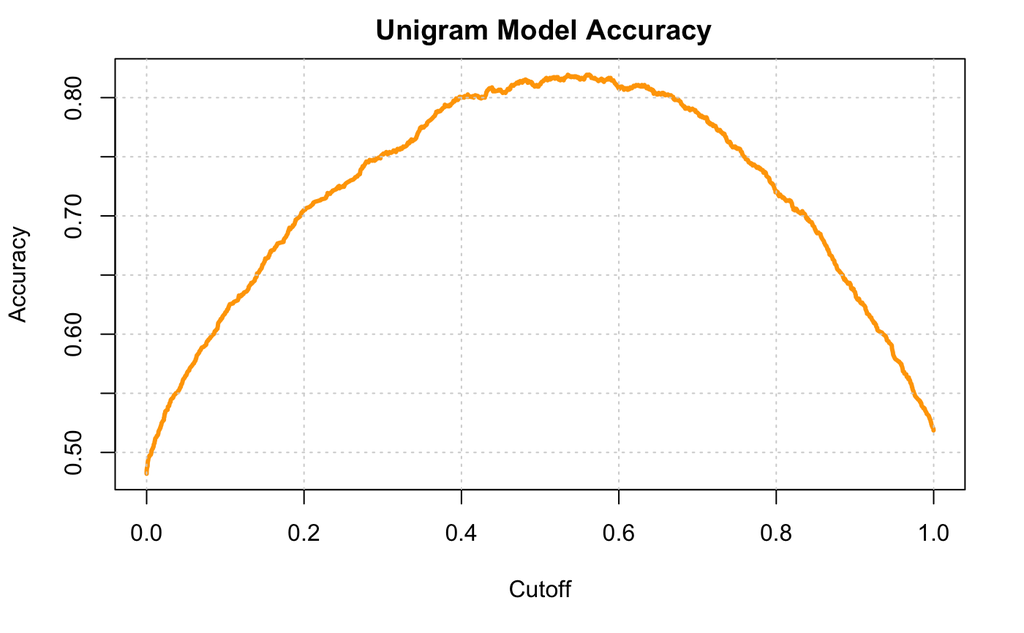

```r
plot(acc,main=" Unigram Model Accuracy",col="orange",lwd=3)
grid()
```

The model’s accuracy is approximately 0.8193333

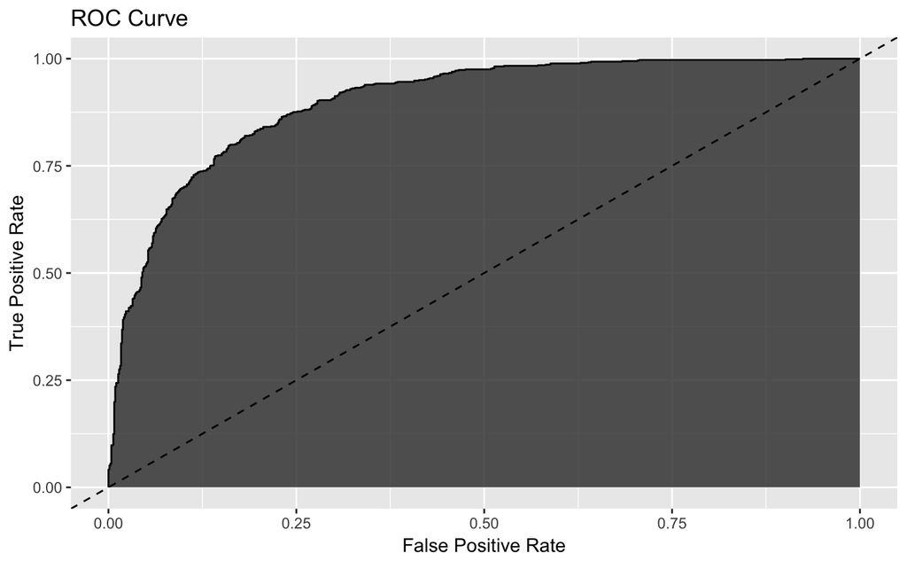

```r
roc.data = data.frame(fpr=unlist(perf@x.values),
                       tpr=unlist(perf@y.values))
ggplot(roc.data, aes(x=fpr, ymin=0, ymax=tpr)) +
    geom_ribbon(alpha=0.8) +
    geom_line(aes(y=tpr)) +
    geom_abline(slope=1, intercept=0, linetype='dashed') +
    ggtitle("ROC Curve") +
    ylab('True Positive Rate') +
    xlab('False Positive Rate')
```

```r
coef_mat = as.matrix(coef(unigram_classifier, s="lambda.min"))
coef_mat = coef_mat[order(coef_mat),]
```

Bottom 20 coefficients - Words that reduce probability of a positive review.

```r
data.frame(head(coef_mat,n = 20))
```

|  | head.coef_mat..n...20. |
| --- | --- |
| worst | -104.59520 |
| awful | -83.21606 |
| poor | -75.75019 |
| dull | -73.34553 |
| waste | -60.65928 |
| poorly | -60.65852 |
| mess | -54.70910 |
| stupid | -54.49920 |
| annoying | -53.36676 |
| unless | -49.83762 |

[output cut: 10 more lines]

Top 20 coefficients - Words that increase probability of a positive review.

```r
data.frame(tail(coef_mat, n = 20))
```

|  | tail.coef_mat..n...20. |
| --- | --- |
| today | 27.84032 |
| overall | 28.69971 |
| wonderful | 29.77673 |
| living | 32.72881 |
| unique | 33.78757 |
| fun | 34.55921 |
| meets | 34.85361 |
| fantastic | 35.13679 |
| atmosphere | 35.98160 |
| highly | 37.65582 |

[output cut: 10 more lines]

## Higher-order N-gram models

Here we repeat the exercise using higher order N-grams.

```r
set.seed(20166)
bigram_vocab = create_vocabulary(train_tokens,stopwords = stop_words, ngram = c( 2L,2L))
```

Prune a little

```r
bigram_vocab =  prune_vocabulary(bigram_vocab,
                   doc_proportion_max = 0.5, term_count_max = 3000)
bigram_vectorizer = vocab_vectorizer(bigram_vocab)
bigram_dtm_train = create_dtm(train_tokens, bigram_vectorizer)
bigram_dtm_train_norm = normalize(bigram_dtm_train, "l1")
bigram_classifier = cv.glmnet(x = bigram_dtm_train_norm, y = training$sentiment,
                 family = 'binomial',
                 alpha = 1,
                 type.measure = "auc",
                 nfolds = NFOLDS,
                 thresh = 1e-3,
                 maxit = 1e3)
```

```r
bigram_dtm_test = create_dtm(testing_tokens, bigram_vectorizer)
#row normalize the data
bigram_dtm_test_norm = normalize(bigram_dtm_test, "l1")
preds_bg = predict(bigram_classifier , bigram_dtm_test_norm , type = 'response',s ="lambda.min")
```

```r
#Create a prediction object
prediction_bg = prediction(preds_bg, testing$sentiment)
#infer True postive and false positve rates
perf_bg = performance(prediction_bg, measure = "tpr", x.measure = "fpr")

#accuracy and area under the curve
acc_bg = performance(prediction_bg, measure = "acc")
max(acc_bg@y.values[[1]])
```

```
[1] 0.7126667
```

```r
auc_bg = performance(prediction_bg, measure = "auc")
auc_bg@y.values
```

```
[[1]]
[1] 0.778383
```

Plot accuracy

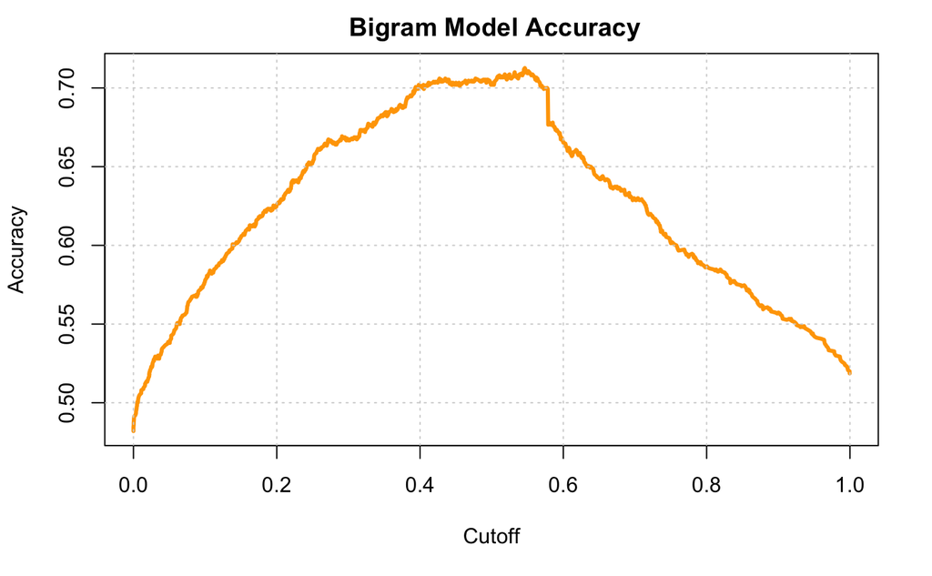

```r
plot(acc_bg,main=" Bigram Model Accuracy",col="orange",lwd=3)
grid()
```

```r
coef_mat_bg = as.matrix(coef(bigram_classifier, s="lambda.min"))
coef_mat_bg = coef_mat_bg[order(coef_mat_bg),]
```

Bottom 20 coefficients - Words that reduce probability of a positive review.

```r
data.frame(head(coef_mat_bg,n = 20))
```

|  | head.coef_mat_bg..n...20. |
| --- | --- |
| not_even | -127.23709 |
| bad_acting | -113.22507 |
| im_sorry | -104.93709 |
| wasted_here | -103.08547 |
| want_make | -99.20827 |
| awful_film | -97.83100 |
| how_bad | -93.26686 |
| all_rest | -93.08688 |
| some_sort | -92.57673 |
| really_bad | -88.43571 |

[output cut: 10 more lines]

Top 20 coefficients - Words that increase probability of a positive review.

```r
data.frame(tail(coef_mat_bg, n = 20))
```

|  | tail.coef_mat_bg..n...20. |
| --- | --- |
| characters_their | 43.47021 |
| one_great | 44.57235 |
| but_still | 44.71902 |
| definitely_worth | 44.79843 |
| very_well | 45.24531 |
| first_time | 47.73768 |
| version_but | 47.80501 |
| help_her | 48.90521 |
| well_deserved | 53.09489 |
| best_film | 53.51503 |

[output cut: 10 more lines]

[figure not shown]

```r
roc.data_bg = data.frame(fpr=unlist(perf_bg@x.values),
                       tpr=unlist(perf_bg@y.values))
ggplot(roc.data_bg, aes(x=fpr, ymin=0, ymax=tpr)) +
    geom_ribbon(alpha=0.8) +
    geom_line(aes(y=tpr)) +
    geom_abline(slope=1, intercept=0, linetype='dashed') +
    ggtitle("ROC Curve") +
    ylab('True Positive Rate') +
    xlab('False Positive Rate')
```